# TMLE Data Summary and Wragling

Jingjing Qi

April 6, 2020; updated 2020-06-11

# Data

## Data Summary

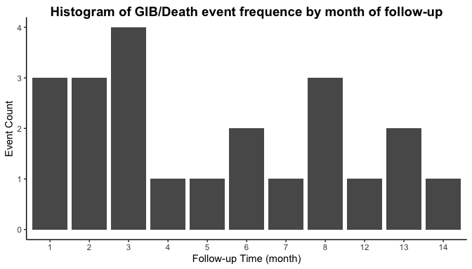

## Censoring, Time Node, Dynamic Treatment Regimes, and Time-Varying Confounders

Data collection sequence follows: $L_0$, $A_0$, $T_1$, $C_1$, $L_1$, $A_1$, $Y_1$, $C_2$,…… $C_t$, $Y_t$, where $C$ is the binary indicator of censoring, $Y$ is the binary indicator of outcome at time node $t$, $A_0$ … $A_{t-1}$ is the binary indicator of treatment exposure of medication of interest (Digoxin or Ace/Arb), $L_0$ is the baseline covariates and $L_1$ … $L_{t-1}$ are the time-varying covariates (lab results and information of medication prescribed in follow-up time node $t$). The data is also assumed to satisfy assumptions of consistency, positivity, and sequential randomization and no unmeasured confounders.

The data is right censored at 18 months after the date of discharge and summarized by time node of a 3 months duration.  
Medication usage of each node is calculate by summing duration in days within each time node, avaliable information in dosage is in cooperated as multiplier to the duration. Lab result of each node is the average values of avaliable information in each time node.

Binary treatment indicator is evaluated by whether the cumulative time of medicine usage is >0.

# Method

## Survival Marginal Structual Model

$\lambda_{T_\overline{a}}(t|L)=\lambda_0(t)exp(\beta_1a(t)+\beta_2Cum.a)$  
where $\lambda_0(t)$ is the unspecified baseline hazard, $\lambda_{T_\overline{a}}(t|L)$ is the hazard of adverse event at time $t$ among subjects followed treatment history $\overline{a}$ through time $t$. The parameter $\beta_1$ is the causal hazard log ratio of Digoxin at time $t$ under dynamic treatment regimes. $\beta_2$ is the causal hazard log ratio of the cumulative Digoxin treatment time $Cum.a$, which is the summarized variable of the empirical treatment regimens observed in the dataset.

# Result

## Digoxin 18-month censoring / 3-month node

### Digoxin Treatment Timeline

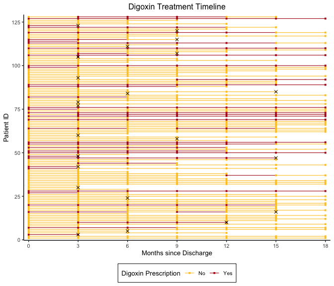

### Time-varying Covariates View

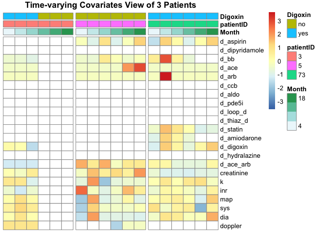

### Dataset View

| strategy | intermacs_class | age_implant | sex_m_male | hypertension | hx_afib_a_flutt | prior_stroke | type2diabetes_0_no_1_yes | smoking_history_or_current | hgt_m | weight_kg | bmi | mcs_support_pre_vad_yes_no | bypass_time | ct_icu_los_post_vad | total_los_includes | creatinine | bun | albumin_g_d_l | tbili | inr | sodium | wbc | platelets | hemoglobin | race | map_discharge | systolic_bp | diastolic_bp | creat_discharge | … |
| --- | --- | --- | --- | --- | --- | --- | --- | --- | --- | --- | --- | --- | --- | --- | --- | --- | --- | --- | --- | --- | --- | --- | --- | --- | --- | --- | --- | --- | --- | --- |
| dt | 2 | 57.73580 | m | no | no | no | no | yes | 1.7140 | 93.0 | 31.65638 | yes | 114 | 25 | 29 | 0.98 | 18 | 10 | 12 | 1.2 | 134 | 8.31 | 105 | 11.5 | other | 86.66667 | 100 | 80 | 0.63 | … |
| dt | 2 | 70.25051 | m | no | yes | no | no | yes | 1.8030 | 111.0 | 34.82210 | yes | 104 | 14 | 34 | 1.00 | 32 | 17 | 6 | 1.2 | 137 | 14.40 | 304 | 10.4 | other | 75.66667 | 97 | 65 | 1.00 | … |
| dt | 2 | 53.80698 | m | no | no | no | no | no | 1.8288 | 100.5 | 30.04925 | no | 82 | 7 | 10 | 1.28 | 12 | 17 | 8 | 1.2 | 137 | 6.82 | 124 | 13.3 | other | 84.66667 | 102 | 76 | 1.28 | … |
| dt | 3 | 69.63723 | m | no | yes | no | no | yes | 1.7010 | 72.1 | 25.54088 | no | 134 | 9 | 10 | 0.94 | 16 | 10 | 5 | 1.2 | 142 | 5.90 | 178 | 13.3 | other | 75.33333 | 94 | 66 | 0.90 | … |
| dt | 3 | 52.29569 | m | no | no | no | no | no | 1.8288 | 84.4 | 25.36097 | no | 79 | 4 | 24 | 1.33 | 26 | 18 | 15 | 1.1 | 135 | 4.40 | 170 | 13.5 | afam | 70.00000 | 84 | 63 | 1.00 | … |
| dt | 2 | 58.39836 | m | yes | no | no | yes | yes | 1.6500 | 81.3 | 29.75207 | no | 52 | 5 | 12 | 1.55 | 28 | 16 | 3 | 1.0 | 140 | 9.52 | 147 | 13.3 | other | 86.00000 | 106 | 76 | 1.24 | … |
| dt | 2 | 43.81383 | m | yes | yes | yes | no | yes | 1.7910 | 115.0 | 35.85145 | yes | 174 | 9 | 24 | 2.01 | 58 | 24 | 6 | 1.2 | 123 | 9.23 | 191 | 13.7 | other | 82.33333 | 103 | 72 | 1.32 | … |
| other | 2 | 43.39767 | m | no | yes | no | no | no | 1.6764 | 79.4 | 29.81870 | yes | 56 | 4 | 13 | 0.98 | 18 | 24 | 5 | 1.1 | 138 | 10.98 | 269 | 13.1 | other | 85.66667 | 101 | 78 | 1.13 | … |
| dt | 4 | 77.32786 | f | yes | yes | no | no | no | 1.6256 | 61.0 | 23.08354 | no | 85 | 7 | 21 | 1.20 | 27 | 21 | 7 | 1.3 | 136 | 4.47 | 169 | 12.0 | other | 79.66667 | 99 | 70 | 0.95 | … |
| dt | 2 | 68.14237 | m | yes | yes | no | yes | no | 1.8000 | 81.5 | 30.24691 | yes | 61 | 28 | 47 | 1.81 | 36 | 9 | 11 | 1.3 | 130 | 12.32 | 284 | 11.7 | afam | 72.66667 | 92 | 63 | 3.74 | … |
| dt | 3 | 60.67077 | m | yes | no | no | no | yes | 1.6764 | 72.0 | 28.14629 | no | 50 | 5 | 23 | 1.79 | 15 | 16 | 7 | 1.2 | 140 | 7.22 | 215 | 12.4 | other | 63.33333 | 76 | 57 | 2.06 | … |
| dt | 2 | 52.08487 | m | yes | yes | no | yes | no | 1.8300 | 130.4 | 38.96802 | yes | 50 | 7 | 23 | 1.64 | 51 | 16 | 13 | 1.2 | 131 | 8.72 | 189 | 13.8 | afam | 74.66667 | 94 | 65 | 1.39 | … |
| dt | 3 | 67.55373 | m | yes | yes | no | no | no | 1.6764 | 107.9 | 41.98815 | no | 57 | 20 | 42 | 1.61 | 35 | 26 | 3 | 1.2 | 138 | 5.54 | 173 | 10.3 | afam | 78.00000 | 92 | 71 | 1.75 | … |
| dt | 2 | 44.30938 | m | no | no | yes | yes | no | 1.8200 | 107.5 | 32.45381 | no | 112 | 21 | 29 | 1.58 | 22 | 14 | 22 | 1.4 | 140 | 8.50 | 214 | 11.5 | afam | 89.00000 | 121 | 73 | 5.69 | … |
| other | 3 | 61.21561 | m | yes | no | no | no | yes | 1.6760 | 96.0 | 38.09217 | no | 47 | 8 | 21 | 1.30 | 14 | 16 | 12 | 1.2 | 143 | 4.90 | 184 | 9.8 | other | 79.33333 | 100 | 69 | 1.37 | … |
| other | 1 | 58.87201 | m | yes | yes | no | yes | no | 1.8540 | 107.5 | 31.50000 | no | 88 | 7 | 24 | 1.54 | 21 | 14 | 24 | 1.3 | 136 | 10.53 | 124 | 16.0 | other | 68.33333 | 87 | 59 | 0.96 | … |
| other | 3 | 49.53593 | m | no | yes | no | yes | yes | 1.7900 | 87.3 | 27.40000 | no | 103 | 7 | 7 | 2.28 | 42 | 25 | 3 | 1.0 | 137 | 12.70 | 195 | 14.3 | other | 71.66667 | 91 | 62 | 1.29 | … |
| other | 3 | 63.85216 | m | no | no | no | no | yes | 1.6800 | 83.3 | 23.38435 | no | 75 | 12 | 7 | 0.90 | 12 | 13 | 9 | 1.0 | 137 | 8.30 | 248 | 13.3 | other | 64.00000 | 80 | 56 | 0.67 | … |
| dt | 2 | 79.76181 | m | yes | no | no | no | no | 1.6000 | 55.9 | 24.60938 | yes | 78 | 5 | 13 | 1.45 | 31 | 15 | 5 | 1.1 | 137 | 12.73 | 226 | 10.4 | other | 75.00000 | 95 | 65 | 0.89 | … |
| dt | 2 | 64.32307 | m | yes | yes | no | no | yes | 1.8796 | 83.0 | 23.49347 | yes | 34 | 36 | 41 | 2.03 | 32 | 14 | 5 | 1.2 | 136 | 10.22 | 120 | 11.5 | other | 76.33333 | 87 | 71 | 0.95 | … |
| dt | 2 | 72.87337 | m | yes | no | no | no | yes | 1.7000 | 83.0 | 30.30000 | yes | 125 | 7 | 30 | 1.26 | 20 | 12 | 7 | 1.2 | 133 | 7.30 | 133 | 12.3 | other | 75.33333 | 90 | 68 | 1.02 | … |
| dt | 3 | 64.16153 | m | yes | yes | no | no | yes | 1.7526 | 70.5 | 23.27772 | no | 56 | 7 | 28 | 0.97 | 12 | 17 | 6 | 1.3 | 137 | 6.46 | 246 | 13.9 | other | 75.66667 | 93 | 67 | 0.90 | … |
| other | 2 | 58.22313 | f | yes | yes | no | no | yes | 1.6783 | 93.5 | 33.01747 | yes | 85 | 131 | 11 | 1.13 | 16 | 17 | 8 | 1.2 | 135 | 7.65 | 101 | 14.7 | other | 70.00000 | 82 | 64 | 1.24 | … |
| other | 3 | 72.22724 | m | no | yes | no | no | yes | 1.8000 | 122.0 | 36.41975 | no | 124 | 7 | 5 | 1.26 | 38 | 24 | 3 | 1.2 | 141 | 5.30 | 147 | 9.9 | other | 68.33333 | 79 | 63 | 1.44 | … |
| dt | 2 | 59.42231 | m | yes | yes | no | yes | yes | 1.9300 | 109.2 | 29.30000 | yes | 107 | 14 | 15 | 1.52 | 23 | 10 | 25 | 1.2 | 129 | 8.50 | 108 | 14.2 | afam | 84.66667 | 120 | 67 | 1.06 | … |
| other | 2 | 52.49555 | m | no | yes | no | yes | no | 1.8034 | 82.6 | 25.24405 | no | 101 | 8 | 12 | 1.30 | 18 | 5 | 4 | 1.0 | 137 | 7.21 | 102 | 13.4 | other | 77.00000 | 91 | 70 | 0.98 | … |
| other | 2 | 52.82409 | f | yes | no | no | yes | no | 1.6200 | 67.0 | 25.52964 | yes | 60 | 7 | 22 | 0.87 | 7 | 12 | 4 | 1.1 | 142 | 8.92 | 138 | 8.8 | afam | 79.00000 | 93 | 72 | 0.70 | … |
| dt | 2 | 52.88433 | m | no | yes | no | no | yes | 1.9050 | 87.7 | 24.38672 | no | 51 | 13 | 8 | 0.92 | 18 | 22 | 10 | 1.2 | 135 | 3.50 | 113 | 11.9 | other | 64.66667 | 86 | 54 | 0.76 | … |
| other | 1 | 33.91376 | f | no | no | no | no | yes | 1.6510 | 70.0 | 27.10000 | yes | 72 | 11 | 39 | 1.95 | 23 | 2 | 1 | 2.1 | 144 | 13.60 | 398 | 9.0 | other | 102.33333 | 129 | 89 | 0.93 | … |
| dt | 2 | 59.37029 | m | yes | yes | no | yes | no | 1.7200 | 81.7 | 29.57680 | no | 288 | 8 | 37 | 1.46 | 43 | 18 | 10 | 1.3 | 135 | 6.56 | 157 | 13.1 | other | 68.00000 | 84 | 60 | 1.58 | … |

[output cut: 98 more lines]

### Unadjusted Cox proportional hazards model

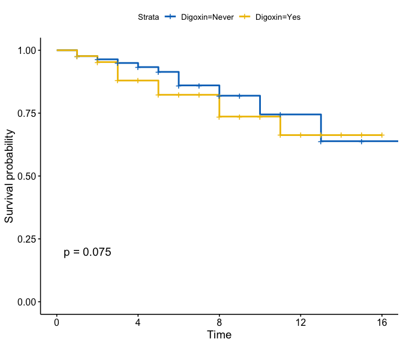

```
## Call:
## survival::coxph(formula = Surv(month_to_outcome, ever_event) ~
##     Digoxin, data = surv_dat)
##
##   n= 768, number of events= 132
##
##              coef exp(coef) se(coef)     z Pr(>|z|)
## DigoxinYes 0.3203    1.3775   0.1797 1.782   0.0747 .
## ---
## Signif. codes:  0 '***' 0.001 '**' 0.01 '*' 0.05 '.' 0.1 ' ' 1
##
##            exp(coef) exp(-coef) lower .95 upper .95
## DigoxinYes     1.377      0.726    0.9685     1.959
##
## Concordance= 0.559  (se = 0.025 )
## Likelihood ratio test= 3.15  on 1 df,   p=0.08
## Wald test            = 3.18  on 1 df,   p=0.07
## Score (logrank) test = 3.2  on 1 df,   p=0.07
```

The unadjusted HR of Digoxin was 1.38 (95% CI: 0.97 - 1.96).

### The covariate-adjusted time-dependent Cox proportional hazards model

```
## Estimator:  tmle
##              Estimate Std. Error   CI 2.5% CI 97.5% p-value
## (Intercept) -4.292572   0.502522 -5.277496   -3.308  <2e-16 ***
## time         0.891351   0.086548  0.721720    1.061  <2e-16 ***
## cum.A        0.010667   0.008873 -0.006723    0.028   0.229
## ---
## Signif. codes:  0 '***' 0.001 '**' 0.01 '*' 0.05 '.' 0.1 ' ' 1
```

The time-dependent covariate-adjusted HR of Digoxin was 1.01 (95% CI: 0.99 - 1.03).

## Ace/Arb 18-month censoring / 3-month node

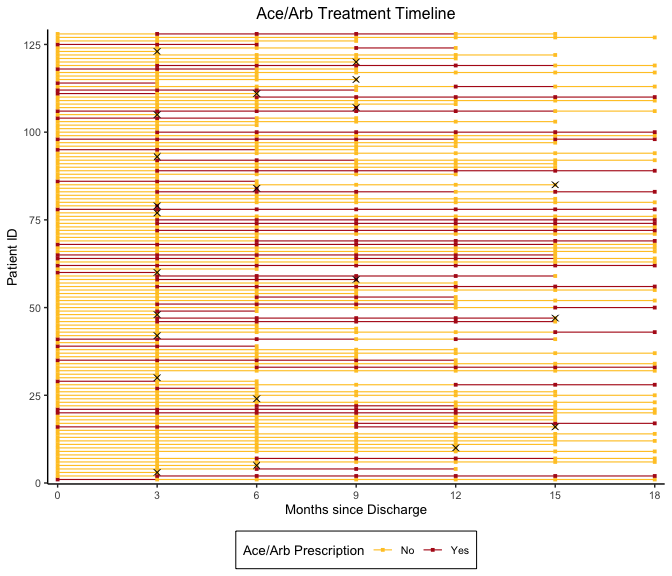

### Time-varying Covariates View

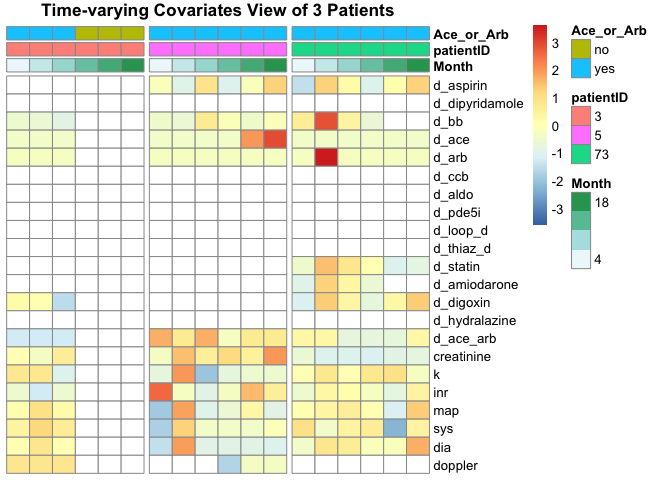

### Dataset View

| strategy | intermacs_class | age_implant | sex_m_male | hypertension | hx_afib_a_flutt | prior_stroke | type2diabetes_0_no_1_yes | smoking_history_or_current | hgt_m | weight_kg | bmi | mcs_support_pre_vad_yes_no | bypass_time | ct_icu_los_post_vad | total_los_includes | creatinine | bun | albumin_g_d_l | tbili | inr | sodium | wbc | platelets | hemoglobin | race | map_discharge | systolic_bp | diastolic_bp | creat_discharge | … |
| --- | --- | --- | --- | --- | --- | --- | --- | --- | --- | --- | --- | --- | --- | --- | --- | --- | --- | --- | --- | --- | --- | --- | --- | --- | --- | --- | --- | --- | --- | --- |
| dt | 2 | 57.73580 | m | no | no | no | no | yes | 1.7140 | 93.0 | 31.65638 | yes | 114 | 25 | 29 | 0.98 | 18 | 10 | 12 | 1.2 | 134 | 8.31 | 105 | 11.5 | other | 86.66667 | 100 | 80 | 0.63 | … |
| dt | 2 | 70.25051 | m | no | yes | no | no | yes | 1.8030 | 111.0 | 34.82210 | yes | 104 | 14 | 34 | 1.00 | 32 | 17 | 6 | 1.2 | 137 | 14.40 | 304 | 10.4 | other | 75.66667 | 97 | 65 | 1.00 | … |
| dt | 2 | 53.80698 | m | no | no | no | no | no | 1.8288 | 100.5 | 30.04925 | no | 82 | 7 | 10 | 1.28 | 12 | 17 | 8 | 1.2 | 137 | 6.82 | 124 | 13.3 | other | 84.66667 | 102 | 76 | 1.28 | … |
| dt | 3 | 69.63723 | m | no | yes | no | no | yes | 1.7010 | 72.1 | 25.54088 | no | 134 | 9 | 10 | 0.94 | 16 | 10 | 5 | 1.2 | 142 | 5.90 | 178 | 13.3 | other | 75.33333 | 94 | 66 | 0.90 | … |
| dt | 3 | 52.29569 | m | no | no | no | no | no | 1.8288 | 84.4 | 25.36097 | no | 79 | 4 | 24 | 1.33 | 26 | 18 | 15 | 1.1 | 135 | 4.40 | 170 | 13.5 | afam | 70.00000 | 84 | 63 | 1.00 | … |
| dt | 2 | 58.39836 | m | yes | no | no | yes | yes | 1.6500 | 81.3 | 29.75207 | no | 52 | 5 | 12 | 1.55 | 28 | 16 | 3 | 1.0 | 140 | 9.52 | 147 | 13.3 | other | 86.00000 | 106 | 76 | 1.24 | … |
| dt | 2 | 43.81383 | m | yes | yes | yes | no | yes | 1.7910 | 115.0 | 35.85145 | yes | 174 | 9 | 24 | 2.01 | 58 | 24 | 6 | 1.2 | 123 | 9.23 | 191 | 13.7 | other | 82.33333 | 103 | 72 | 1.32 | … |
| other | 2 | 43.39767 | m | no | yes | no | no | no | 1.6764 | 79.4 | 29.81870 | yes | 56 | 4 | 13 | 0.98 | 18 | 24 | 5 | 1.1 | 138 | 10.98 | 269 | 13.1 | other | 85.66667 | 101 | 78 | 1.13 | … |
| dt | 4 | 77.32786 | f | yes | yes | no | no | no | 1.6256 | 61.0 | 23.08354 | no | 85 | 7 | 21 | 1.20 | 27 | 21 | 7 | 1.3 | 136 | 4.47 | 169 | 12.0 | other | 79.66667 | 99 | 70 | 0.95 | … |
| dt | 2 | 68.14237 | m | yes | yes | no | yes | no | 1.8000 | 81.5 | 30.24691 | yes | 61 | 28 | 47 | 1.81 | 36 | 9 | 11 | 1.3 | 130 | 12.32 | 284 | 11.7 | afam | 72.66667 | 92 | 63 | 3.74 | … |
| dt | 3 | 60.67077 | m | yes | no | no | no | yes | 1.6764 | 72.0 | 28.14629 | no | 50 | 5 | 23 | 1.79 | 15 | 16 | 7 | 1.2 | 140 | 7.22 | 215 | 12.4 | other | 63.33333 | 76 | 57 | 2.06 | … |
| dt | 2 | 52.08487 | m | yes | yes | no | yes | no | 1.8300 | 130.4 | 38.96802 | yes | 50 | 7 | 23 | 1.64 | 51 | 16 | 13 | 1.2 | 131 | 8.72 | 189 | 13.8 | afam | 74.66667 | 94 | 65 | 1.39 | … |
| dt | 3 | 67.55373 | m | yes | yes | no | no | no | 1.6764 | 107.9 | 41.98815 | no | 57 | 20 | 42 | 1.61 | 35 | 26 | 3 | 1.2 | 138 | 5.54 | 173 | 10.3 | afam | 78.00000 | 92 | 71 | 1.75 | … |
| dt | 2 | 44.30938 | m | no | no | yes | yes | no | 1.8200 | 107.5 | 32.45381 | no | 112 | 21 | 29 | 1.58 | 22 | 14 | 22 | 1.4 | 140 | 8.50 | 214 | 11.5 | afam | 89.00000 | 121 | 73 | 5.69 | … |
| other | 3 | 61.21561 | m | yes | no | no | no | yes | 1.6760 | 96.0 | 38.09217 | no | 47 | 8 | 21 | 1.30 | 14 | 16 | 12 | 1.2 | 143 | 4.90 | 184 | 9.8 | other | 79.33333 | 100 | 69 | 1.37 | … |
| other | 1 | 58.87201 | m | yes | yes | no | yes | no | 1.8540 | 107.5 | 31.50000 | no | 88 | 7 | 24 | 1.54 | 21 | 14 | 24 | 1.3 | 136 | 10.53 | 124 | 16.0 | other | 68.33333 | 87 | 59 | 0.96 | … |
| other | 3 | 49.53593 | m | no | yes | no | yes | yes | 1.7900 | 87.3 | 27.40000 | no | 103 | 7 | 7 | 2.28 | 42 | 25 | 3 | 1.0 | 137 | 12.70 | 195 | 14.3 | other | 71.66667 | 91 | 62 | 1.29 | … |
| other | 3 | 63.85216 | m | no | no | no | no | yes | 1.6800 | 83.3 | 23.38435 | no | 75 | 12 | 7 | 0.90 | 12 | 13 | 9 | 1.0 | 137 | 8.30 | 248 | 13.3 | other | 64.00000 | 80 | 56 | 0.67 | … |
| dt | 2 | 79.76181 | m | yes | no | no | no | no | 1.6000 | 55.9 | 24.60938 | yes | 78 | 5 | 13 | 1.45 | 31 | 15 | 5 | 1.1 | 137 | 12.73 | 226 | 10.4 | other | 75.00000 | 95 | 65 | 0.89 | … |
| dt | 2 | 64.32307 | m | yes | yes | no | no | yes | 1.8796 | 83.0 | 23.49347 | yes | 34 | 36 | 41 | 2.03 | 32 | 14 | 5 | 1.2 | 136 | 10.22 | 120 | 11.5 | other | 76.33333 | 87 | 71 | 0.95 | … |
| dt | 2 | 72.87337 | m | yes | no | no | no | yes | 1.7000 | 83.0 | 30.30000 | yes | 125 | 7 | 30 | 1.26 | 20 | 12 | 7 | 1.2 | 133 | 7.30 | 133 | 12.3 | other | 75.33333 | 90 | 68 | 1.02 | … |
| dt | 3 | 64.16153 | m | yes | yes | no | no | yes | 1.7526 | 70.5 | 23.27772 | no | 56 | 7 | 28 | 0.97 | 12 | 17 | 6 | 1.3 | 137 | 6.46 | 246 | 13.9 | other | 75.66667 | 93 | 67 | 0.90 | … |
| other | 2 | 58.22313 | f | yes | yes | no | no | yes | 1.6783 | 93.5 | 33.01747 | yes | 85 | 131 | 11 | 1.13 | 16 | 17 | 8 | 1.2 | 135 | 7.65 | 101 | 14.7 | other | 70.00000 | 82 | 64 | 1.24 | … |
| other | 3 | 72.22724 | m | no | yes | no | no | yes | 1.8000 | 122.0 | 36.41975 | no | 124 | 7 | 5 | 1.26 | 38 | 24 | 3 | 1.2 | 141 | 5.30 | 147 | 9.9 | other | 68.33333 | 79 | 63 | 1.44 | … |
| dt | 2 | 59.42231 | m | yes | yes | no | yes | yes | 1.9300 | 109.2 | 29.30000 | yes | 107 | 14 | 15 | 1.52 | 23 | 10 | 25 | 1.2 | 129 | 8.50 | 108 | 14.2 | afam | 84.66667 | 120 | 67 | 1.06 | … |
| other | 2 | 52.49555 | m | no | yes | no | yes | no | 1.8034 | 82.6 | 25.24405 | no | 101 | 8 | 12 | 1.30 | 18 | 5 | 4 | 1.0 | 137 | 7.21 | 102 | 13.4 | other | 77.00000 | 91 | 70 | 0.98 | … |
| other | 2 | 52.82409 | f | yes | no | no | yes | no | 1.6200 | 67.0 | 25.52964 | yes | 60 | 7 | 22 | 0.87 | 7 | 12 | 4 | 1.1 | 142 | 8.92 | 138 | 8.8 | afam | 79.00000 | 93 | 72 | 0.70 | … |
| dt | 2 | 52.88433 | m | no | yes | no | no | yes | 1.9050 | 87.7 | 24.38672 | no | 51 | 13 | 8 | 0.92 | 18 | 22 | 10 | 1.2 | 135 | 3.50 | 113 | 11.9 | other | 64.66667 | 86 | 54 | 0.76 | … |
| other | 1 | 33.91376 | f | no | no | no | no | yes | 1.6510 | 70.0 | 27.10000 | yes | 72 | 11 | 39 | 1.95 | 23 | 2 | 1 | 2.1 | 144 | 13.60 | 398 | 9.0 | other | 102.33333 | 129 | 89 | 0.93 | … |
| dt | 2 | 59.37029 | m | yes | yes | no | yes | no | 1.7200 | 81.7 | 29.57680 | no | 288 | 8 | 37 | 1.46 | 43 | 18 | 10 | 1.3 | 135 | 6.56 | 157 | 13.1 | other | 68.00000 | 84 | 60 | 1.58 | … |

[output cut: 98 more lines]

### Unadjusted Cox proportional hazards model

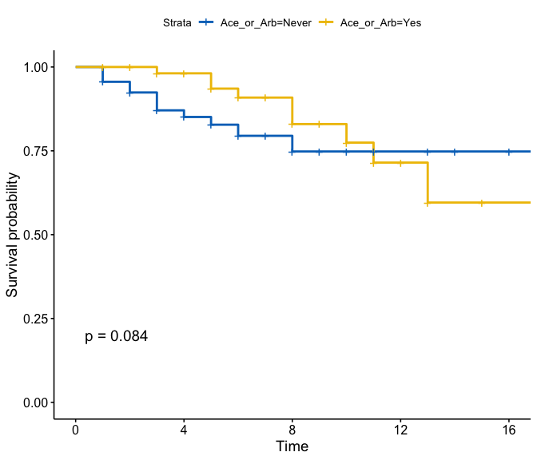

```
## Call:
## survival::coxph(formula = Surv(month_to_outcome, ever_event) ~
##     Ace_or_Arb, data = surv_dat)
##
##   n= 768, number of events= 132
##
##                  coef exp(coef) se(coef)      z Pr(>|z|)
## Ace_or_ArbYes -0.2763    0.7586   0.1770 -1.561    0.118
##
##               exp(coef) exp(-coef) lower .95 upper .95
## Ace_or_ArbYes    0.7586      1.318    0.5363     1.073
##
## Concordance= 0.623  (se = 0.02 )
## Likelihood ratio test= 2.45  on 1 df,   p=0.1
## Wald test            = 2.44  on 1 df,   p=0.1
## Score (logrank) test = 2.45  on 1 df,   p=0.1
```

The unadjusted HR of Ace/Arb was 0.76 (95% CI: 0.54 - 1.07).

### The covariate-adjusted time-dependent Cox proportional hazards model

```
## Estimator:  tmle
##              Estimate Std. Error   CI 2.5% CI 97.5% p-value
## (Intercept) -3.783176   0.328662 -4.427342   -3.139  <2e-16 ***
## time         0.840904   0.055863  0.731414    0.950  <2e-16 ***
## cum.A       -0.051518   0.004707 -0.060745   -0.042  <2e-16 ***
## ---
## Signif. codes:  0 '***' 0.001 '**' 0.01 '*' 0.05 '.' 0.1 ' ' 1
```

The time-dependent covariate-adjusted HR of Ace/Arb was 0.95 (95% CI: 0.94 - 0.96).